# Relatório de Planejamento e Análise de Experimentos

Clevia Bento de Oliveira

22/09/2021

# Relatório referente à análise de um banco de dados em DBC, utilizando parcela subdividida.

## Introdução

No experimento em parcelas subdivididas, as parcelas experimentais são divididas em sub parcelas. São estudados dois ou mais fatores simultaneamente, tais fatores são chamados primários, secundários e assim por diante.

Os fatores primários são aleatorizados nas parcelas, os secundários nas sub parcelas. O modelo linear para o experimento em parcelas subdivididas no delineamento em blocos ao acaso  
é dado por:

*yijk = µ + τi + βj + eij + θk + γik + Ɛikj*  
onde:

- µ é a média geral;
- τi é o efeito do i-ésimo tratamento sobre a variável resposta;
- βj é o efeito do j-ésimo bloco sobre a variável resposta;
- eik é o resíduo aleatório à nível de parcelas;
- θk é o efeito do k-ésimo sub-tratamento sobre a variável resposta;
- γik é o efeito da interação do i-ésimo tratamento com o j-ésimo subtratamento sobre a variável resposta;
- Ɛijk é o resíduo aleatório associado a observação yijk à nível de sub-parcelas.

Neste trabalho será analisado um banco de dados fictício de um experimento em blocos casualizados, onde há 3 espécies diferentes de cultivares (CULT1, CULT2 e CULT3), 4 tipos diferentes de irrigação (irrigacao1,irrigacao2,irrigacao3 e irrigacao4) com 3 repetições em blocos casualizados.

### Objetivo:

Comparar se há diferença significativa de produção no plantio de diferentes espécies de cultivares e diferentes tipos de irrigação.

### Metodologia

Para esta análise será utilizado o pacote `ExpDes.pt` para obter a ANOVA e demais resultados.

### Visualização dos 10 primeiros dados do Banco de Dados

| Cultivares | Irrigacao | Bloco | Prod |
| --- | --- | --- | --- |
| CULT1 | irrigacao1 | 1 | 66 |
| CULT1 | irrigacao1 | 2 | 64 |
| CULT1 | irrigacao1 | 3 | 76 |
| CULT1 | irrigacao2 | 1 | 70 |
| CULT1 | irrigacao2 | 2 | 67 |
| CULT1 | irrigacao2 | 3 | 83 |
| CULT1 | irrigacao3 | 1 | 63 |
| CULT1 | irrigacao3 | 2 | 61 |
| CULT1 | irrigacao3 | 3 | 69 |
| CULT1 | irrigacao4 | 1 | 57 |

### Análise Descritiva

```
##  Cultivares      Irrigacao     Bloco        Prod
##  CULT1:12   irrigacao1:9   Min.   :1   60     : 2
##  CULT2:12   irrigacao2:9   1st Qu.:1   66     : 2
##  CULT3:12   irrigacao3:9   Median :2   68     : 2
##             irrigacao4:9   Mean   :2   69     : 2
##                            3rd Qu.:3   70     : 2
##                            Max.   :3   71     : 2
##                                        (Other):24
```

```
## tibble [36 x 4] (S3: tbl_df/tbl/data.frame)
##  $ Cultivares: Factor w/ 3 levels "CULT1","CULT2",..: 1 1 1 1 1 1 1 1 1 1 ...
##  $ Irrigacao : Factor w/ 4 levels "irrigacao1","irrigacao2",..: 1 1 1 2 2 2 3 3 3 4 ...
##  $ Bloco     : num [1:36] 1 2 3 1 2 3 1 2 3 1 ...
##  $ Prod      : Factor w/ 27 levels "57","59","60",..: 7 6 16 11 8 20 5 4 10 1 ...
```

### Visualização do Experimento

Aqui vemos a Irrigação dado os Cultivares

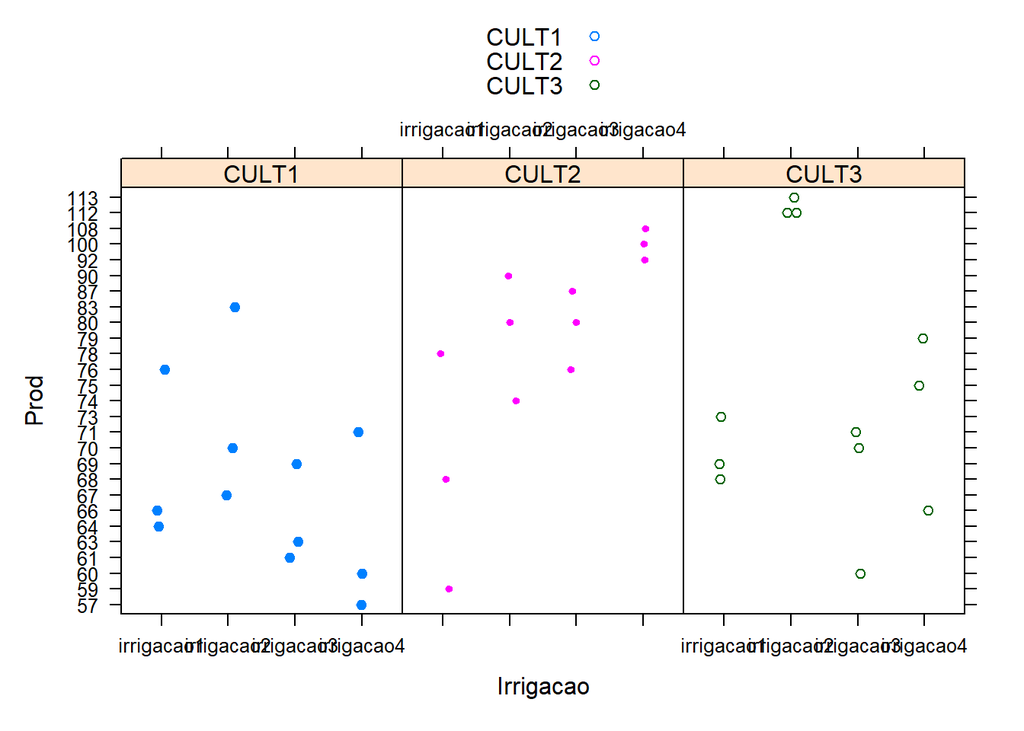

Aqui vemos os Cultivares dada a Irrigação

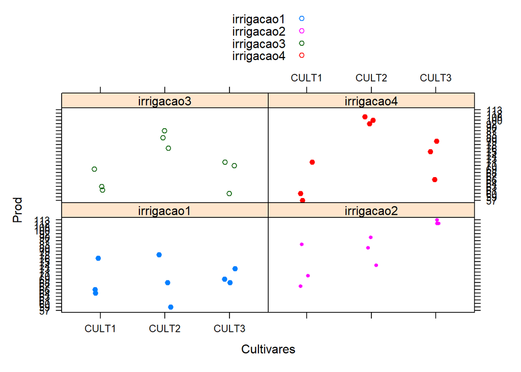

### Teste de Hipóteses

#### Hipóteses que queremos testar:

H0: Não há diferença entre as irrigações em relação a produtividade.  
H1: Há influência da irrigação na produtividade.

H0:Não diferença entre os blocos.  
H1: Há diferença entre os blocos.

H0: Não há diferença entre os cultivares na produtividade.  
H1: Há diferença dos cultivares na produção.

H0: A interação entre os cultivares e irrigação não é significativa.  
H1: A interação é significativa.

```r
dados1.av = aov(Prod ~  Cultivares*Irrigacao + Error(Bloco:Cultivares))
summary(dados1.av)
```

```
##
## Error: Bloco:Cultivares
##            Df Sum Sq Mean Sq F value Pr(>F)
## Cultivares  2   1408   704.2   1.476  0.503
## Residuals   1    477   477.0
##
## Error: Within
##                      Df Sum Sq Mean Sq F value   Pr(>F)
## Cultivares            2    399   199.4   9.263  0.00131 **
## Irrigacao             3   2245   748.3  34.767 2.49e-08 ***
## Cultivares:Irrigacao  6   3563   593.9  27.596 6.33e-09 ***
## Residuals            21    452    21.5
## ---
## Signif. codes:  0 '***' 0.001 '**' 0.01 '*' 0.05 '.' 0.1 ' ' 1
```

### Análise de Resíduos

```r
dados.avb = aov(Prod ~ Cultivares*Irrigacao + Bloco*Cultivares-Bloco)
summary(dados.avb)
```

```
##                      Df Sum Sq Mean Sq F value   Pr(>F)
## Cultivares            2   1687   843.4  39.186 8.17e-08 ***
## Irrigacao             3   2245   748.3  34.767 2.49e-08 ***
## Cultivares:Irrigacao  6   3564   593.9  27.596 6.33e-09 ***
## Cultivares:Bloco      3    597   199.1   9.252 0.000425 ***
## Residuals            21    452    21.5
## ---
## Signif. codes:  0 '***' 0.001 '**' 0.01 '*' 0.05 '.' 0.1 ' ' 1
```

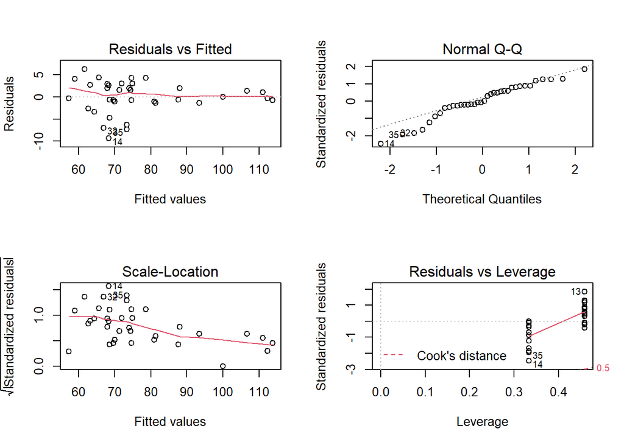

```r
par(mfrow=c(2,2))
plot(dados.avb)
```

### Teste de Normalidade

```r
shapiro.test(dados.avb$residuals)
```

```
##
##  Shapiro-Wilk normality test
##
## data:  dados.avb$residuals
## W = 0.93821, p-value = 0.0447
```

```
## [1] "14" "5"  "32"
```

```
## [1] "14" "32" "35"
```

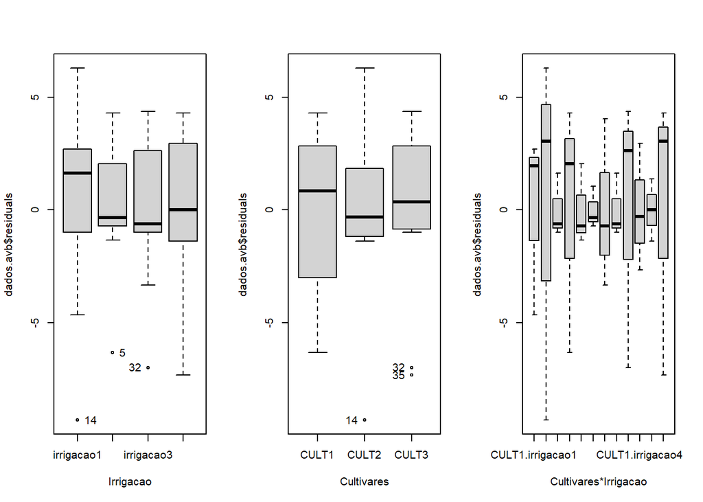

```
##
##  Bartlett test of homogeneity of variances
##
## data:  dados.avb$residuals and Irrigacao
## Bartlett's K-squared = 1.5667, df = 3, p-value = 0.667
```

```
##
##  Bartlett test of homogeneity of variances
##
## data:  dados.avb$residuals and Cultivares
## Bartlett's K-squared = 0.059896, df = 2, p-value = 0.9705
```

### Análise utilizando o pacote `ExpDes.pt`

```r
require(ExpDes.pt)
psub2.dbc(Cultivares, Irrigacao, Bloco, Prod, quali = c(TRUE, TRUE),mcomp = "tukey",
          fac.names = c("Cultivares", "Irrigação"), sigF = 0.05)
```

```
## ------------------------------------------------------------------------
## Legenda:
## FATOR 1 (parcela):  Cultivares
## FATOR 2 (subparcela):  Irrigação
## ------------------------------------------------------------------------
##
## ------------------------------------------------------------------------
## $`Quadro da analise de variancia\n------------------------------------------------------------------------\n`
##                      GL     SQ     QM     Fc   Pr(>Fc)
## Cultivares            2 1686.7 843.36 26.750  0.004839 **
## Bloco                 2  722.7 361.36 11.462  0.022073 *
## Erro a                4  126.1  31.53
## Irrigação             3 2244.8 748.25 67.175 < 2.2e-16 ***
## Cultivares*Irrigação  6 3563.5 593.92 53.319 < 2.2e-16 ***
## Erro b               18  200.5  11.14
## Total                35 8544.3
## ---
## Signif. codes:  0 '***' 0.001 '**' 0.01 '*' 0.05 '.' 0.1 ' ' 1
##
## ------------------------------------------------------------------------
## CV 1 = 7.305333 %
## CV 2 = 4.342245 %
##
##
##
## Interacao significativa: desdobrando a interacao
## ------------------------------------------------------------------------
##
## Desdobrando  Cultivares  dentro de cada nivel de  Irrigação
## ------------------------------------------------------------------------
##                                          GL          SQ          QM        Fc
## Cultivares : Irrigação irrigacao1   2.00000    4.666667    2.333333  0.143713
## Cultivares : Irrigação irrigacao2   2.00000 2546.000000 1273.000000 78.405474
## Cultivares : Irrigação irrigacao3   2.00000  480.888889  240.444444 14.809239
## Cultivares : Irrigação irrigacao4   2.00000 2218.666667 1109.333333 68.325064
## Erro combinado                     13.58219  220.521944   16.236111
##                                     valor.p
## Cultivares : Irrigação irrigacao1  0.867436
## Cultivares : Irrigação irrigacao2         0
## Cultivares : Irrigação irrigacao3  0.000387
```

[output cut: 78 more lines]

```
## ------------------------------------------------------------------------
## ------------------------------------------------------------------------
##
##
##  Irrigação dentro de Cultivares CULT3
## ------------------------------------------------------------------------
## Teste de Tukey
## ------------------------------------------------------------------------
## Grupos Tratamentos Medias
## a     irrigacao2      112.3333
##  b    irrigacao4      73.33333
##  b    irrigacao1      70
##  b    irrigacao3      67
## ------------------------------------------------------------------------
## ------------------------------------------------------------------------
```

## Conclusão

Pela análise de Variâncias as interações foram significativas. Sendo assim há diferença significativa tanto entre as Irrigações quanto nos Cultivares.  
Também há diferença significativa na interação dos fatores.  
Analisando os desdobramentos temos que:  
Para a Irrigação 1, os Cultivares não apresentaram diferença significatica.  
Para a Irrigação 2, o Cultivar 3 teve melhor desempenho, seguido do Cultivar 2.  
Para a Irrigação 3, o Cultivar 2 teve melhor desempenho.  
Para a Irrigação 4, o Cultivar 2 teve melhor desempenho. Com isso podemos concluir que dentre os 3 Cultivares, o Cultivar 2 apresenta melhores resultados  
em relação ás Irrigações.

Para o Cultivar 1, a Irrigação 2 apresenta melhores resultados.  
Para o Cultivar 2, a Irrigação 4 apresenta melhores resultados.  
Para o Cultivar 3, a Irrigação 2 apresenta melhores resultados.  
Podemos concluir que dentre as 4 Irrigações, a Irrigação 2 apresenta melhores resultados  
em relação aos Cultivares.